# Single-cell RNA-seq from start to finish: beginner

PBMCs from 8 donors, control vs interferon-beta (Kang et al. 2018)

Author

Andrew Milner

This is one complete single-cell analysis on a laptop, from a count matrix to pathways. Every step says what we do and why we do it. Most Seurat tutorials cover one step each, so you have to stitch them together yourself. Here everything is in one place and in order.

**The data.** Blood cells (PBMCs) from 8 people. Each person’s cells were split in two: one half left alone (`ctrl`) and one half treated with interferon-beta (`stim`). That gives us 8 control samples and 8 treated samples, and every treated sample has a matching control from the same person. It was run on 10x Genomics Chromium.

**The question.** Which genes and pathways change in each cell type when cells are treated with interferon-beta?

**The steps.**

1. Load the data
2. Remove ambient RNA
3. Find doublets
4. Quality control
5. Normalize
6. Integrate
7. Cluster and UMAP
8. Find marker genes
9. Name the clusters
10. Differential expression between conditions (pseudobulk)
11. Pathway analysis
12. Save

Want to run it yourself? The [setup steps](https://github.com/armilner/scrnaseq-tutorial/tree/main/beginner#step-1-install-r) cover installing R and RStudio, the packages, and running this file. No experience needed.

```r
library(Seurat)
library(SingleCellExperiment)
library(muscData)     # the example data
library(celda)        # decontX, for ambient RNA
library(scDblFinder)  # doublets
library(scuttle)      # QC helper
library(harmony)      # integration
library(DESeq2)       # differential expression
library(fgsea)        # pathway analysis
library(msigdbr)      # gene sets
library(ggplot2)
library(dplyr)

set.seed(42)  # so you get the same results every time
dir.create("results", showWarnings = FALSE)
```

## 1. Load the data

**What:** download the count matrix. Rows are genes, columns are cells, and each value is how many RNA molecules of that gene were counted in that cell.

**Why:** everything else starts from these raw counts. The first download takes a minute, and after that the file is cached.

```r
sce <- Kang18_8vs8()
sce
```

```
class: SingleCellExperiment
dim: 35635 29065
metadata(0):
assays(1): counts
rownames(35635): MIR1302-10 FAM138A ... MT-ND6 MT-CYB
rowData names(2): ENSEMBL SYMBOL
colnames(29065): AAACATACAATGCC-1 AAACATACATTTCC-1 ... TTTGCATGGTTTGG-1
  TTTGCATGTCTTAC-1
colData names(5): ind stim cluster cell multiplets
reducedDimNames(1): TSNE
mainExpName: NULL
altExpNames(0):
```

A few genes appear more than once, for example `CD79A_ENSG00000105369` and `CD79A_ENSG00000272985`. The extra copies come from alternative versions of some chromosome regions and have almost no counts. We keep the copy with the most counts for each gene and give it its plain name, so that names like `CD79A` work in plots and match the pathway gene sets later.

```r
total_counts <- rowSums(counts(sce))
sce <- sce[order(total_counts, decreasing = TRUE), ]
sce <- sce[!duplicated(rowData(sce)$SYMBOL), ]
rownames(sce) <- rowData(sce)$SYMBOL
nrow(sce)
```

```
[1] 32938
```

The table that comes with the cells tells us who each cell came from (`ind`), whether it was treated (`stim`), and what the original authors called it (`cell`). It also has a `multiplets` column, which we come back to in step 3.

```r
# how many cells per person and condition
table(sce$ind, sce$stim)
```

```
       ctrl stim
  101  1027 1363
  107   645  641
  1015 3138 2703
  1016 2180 1998
  1039  552  797
  1244 2250 1755
  1256 2451 2275
  1488 2376 2914
```

We make one sample name per person and condition, like `donor101-ctrl`. This is the unit we compare later.

```r
sce$sample <- paste0("donor", sce$ind, "-", sce$stim)
```

In this experiment all control cells were run in one 10x lane and all treated cells in another. A lane is called a capture. Ambient RNA and doublets happen inside one capture, so steps 2 to 4 are done separately for each capture. Here the capture is the same as `stim`.

## 2. Remove ambient RNA

**What:** when cells are loaded, some float-around RNA from broken cells ends up in every droplet. This is called ambient RNA or soup. We estimate how much each cell has and subtract it.

**Why:** without this, genes from very common cells show up in every cell type. For example, monocyte genes can appear in T cells. This makes clusters look mixed and can create false differences later.

**Which tool:** if you have the `raw_feature_bc_matrix` from Cell Ranger (all droplets, including empty ones), SoupX is the usual choice. This dataset only has the cells, with no empty droplets, so we use **decontX**. It works out the contamination from the cells alone.

```r
sce <- decontX(sce, batch = sce$stim, verbose = FALSE)

# contamination per cell, from 0 (none) to 1 (all soup)
summary(sce$decontX_contamination)
```

```
     Min.   1st Qu.    Median      Mean   3rd Qu.      Max.
0.0000771 0.0094743 0.0276354 0.0709858 0.0789133 0.8500350
```

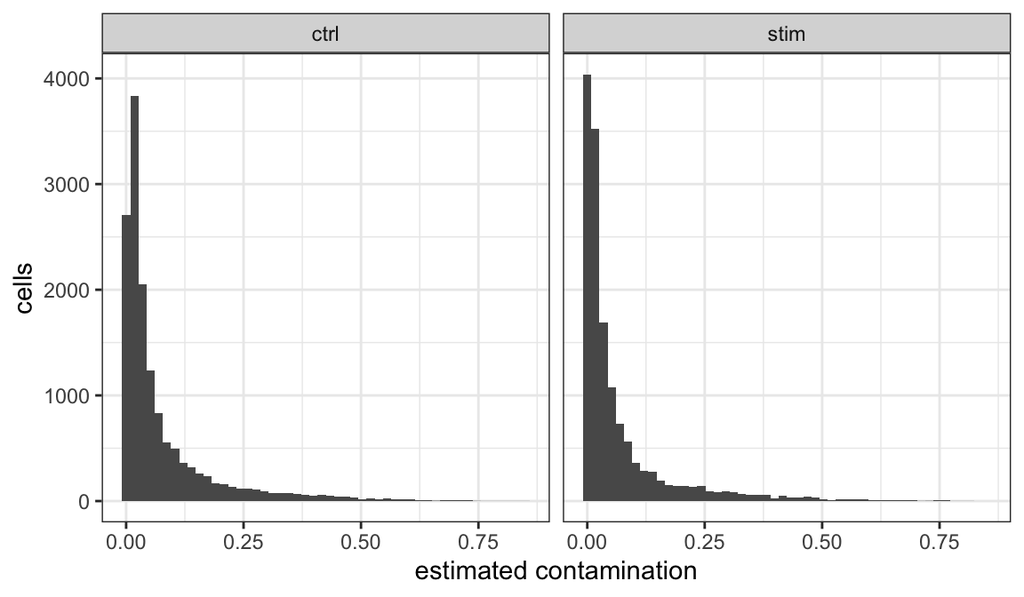

```r
ggplot(as.data.frame(colData(sce)), aes(decontX_contamination)) +
  geom_histogram(bins = 50) +
  facet_wrap(~stim) +
  labs(x = "estimated contamination", y = "cells") +
  theme_bw()
```

Most cells have a small amount of contamination. We keep the corrected counts, rounded to whole numbers because later steps expect counts.

```r
corrected <- round(decontXcounts(sce))
```

## 3. Find doublets

**What:** sometimes two cells land in the same droplet. That droplet looks like one cell that expresses the genes of both, for example a T cell and a B cell at once. These are doublets.

**Why:** doublets can form fake clusters that look like a new cell type. We want to remove them before clustering.

**How:** scDblFinder makes fake doublets by adding random pairs of cells together, then learns what doublets look like and scores every real cell. It runs on each capture separately because doublets can only form inside one capture.

```r
sce_clean <- SingleCellExperiment(list(counts = corrected), colData = colData(sce))
sce_clean <- scDblFinder(sce_clean, samples = "stim")
table(sce_clean$scDblFinder.class)
```

```
singlet doublet
  25759    3306
```

This dataset has a bonus. The authors mixed cells from 8 people in each lane and used each person’s DNA differences (with a tool called demuxlet) to find droplets containing two people. That is in the `multiplets` column. Let’s compare the two.

```r
table(scDblFinder = sce_clean$scDblFinder.class, demuxlet = sce_clean$multiplets)
```

```
           demuxlet
scDblFinder  ambs doublet singlet
    singlet  1150    1507   23102
    doublet    67    1662    1577
```

demuxlet can only see doublets made of two different people, and scDblFinder can only see doublets made of two different cell types, so they catch different droplets. We remove a cell if either tool calls it a doublet. demuxlet’s `ambs` (ambiguous) cells are also removed, because we can’t tell which person they came from.

## 4. Quality control

**What:** remove cells that look broken or empty.

**Why:** a cell with very few genes is probably a broken cell or an empty droplet. A cell with a lot of mitochondrial RNA is often a dying cell that has lost most of its other RNA. These cells cluster together and look like a separate cell type when they are not.

First we put the data into Seurat, which we use for the rest of the analysis. We also keep the uncorrected counts as a second assay, so you can compare later.

```r
obj <- CreateSeuratObject(counts = corrected, meta.data = as.data.frame(colData(sce_clean)))
obj[["uncorrected"]] <- CreateAssay5Object(counts = counts(sce))
obj[["percent.mt"]] <- PercentageFeatureSet(obj, pattern = "^MT-")
obj
```

```
An object of class Seurat
65876 features across 29065 samples within 2 assays
Active assay: RNA (32938 features, 0 variable features)
 1 layer present: counts
 1 other assay present: uncorrected
```

The three numbers we look at:

- `nCount_RNA`: total RNA molecules in the cell
- `nFeature_RNA`: number of different genes found in the cell
- `percent.mt`: percent of RNA from mitochondrial genes

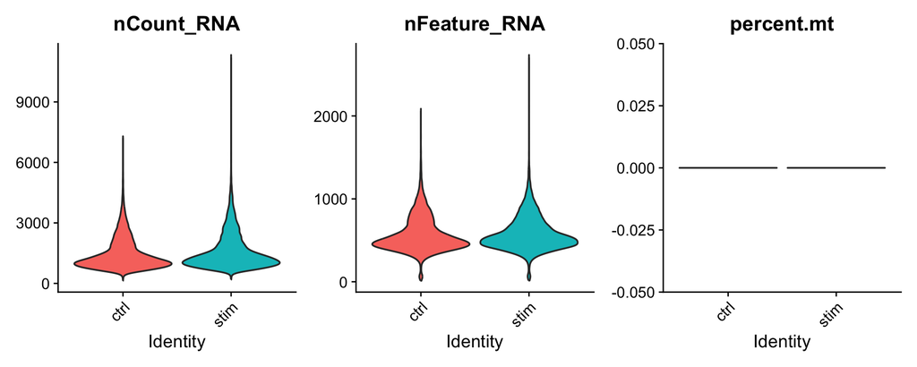

```r
VlnPlot(obj, features = c("nCount_RNA", "nFeature_RNA", "percent.mt"),
        group.by = "stim", pt.size = 0, ncol = 3)
```

**How to pick cutoffs.** Don’t copy numbers from another dataset. Instead, flag cells that are far from the middle of their own capture. “Far” here means more than 3 MADs (median absolute deviations, a robust version of the standard deviation). We use log values because counts are skewed.

For mitochondrial percent we only flag the high side. We also never set that cutoff below 10%, because in healthy blood cells mito is low and a pure MAD rule would throw out good cells.

```r
low_counts   <- isOutlier(obj$nCount_RNA,   nmads = 3, log = TRUE, type = "lower",  batch = obj$stim)
high_counts  <- isOutlier(obj$nCount_RNA,   nmads = 3, log = TRUE, type = "higher", batch = obj$stim)
low_genes    <- isOutlier(obj$nFeature_RNA, nmads = 3, log = TRUE, type = "lower",  batch = obj$stim)
high_mito    <- isOutlier(obj$percent.mt,   nmads = 3, type = "higher", batch = obj$stim)
high_mito    <- high_mito & obj$percent.mt > 10

obj$qc_fail <- low_counts | high_counts | low_genes | high_mito
obj$doublet <- obj$scDblFinder.class == "doublet" | obj$multiplets != "singlet"
```

How many cells each rule removes, per capture:

```r
qc_table <- data.frame(
  capture      = c("ctrl", "stim"),
  cells        = as.vector(table(obj$stim)),
  low_counts   = as.vector(tapply(low_counts,  obj$stim, sum)),
  high_counts  = as.vector(tapply(high_counts, obj$stim, sum)),
  low_genes    = as.vector(tapply(low_genes,   obj$stim, sum)),
  high_mito    = as.vector(tapply(high_mito,   obj$stim, sum)),
  doublets     = as.vector(tapply(obj$doublet, obj$stim, sum)),
  kept         = as.vector(tapply(!obj$qc_fail & !obj$doublet, obj$stim, sum))
)
qc_table
```

```
  capture cells low_counts high_counts low_genes high_mito doublets  kept
1    ctrl 14619          6          48       155         0     3103 11417
2    stim 14446         10          32       145         0     2860 11497
```

```r
write.csv(qc_table, "results/qc_table.csv", row.names = FALSE)
```

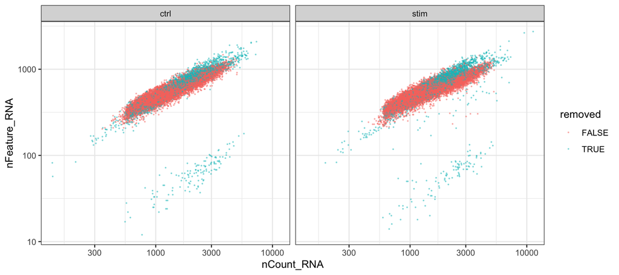

```r
obj$removed <- obj$qc_fail | obj$doublet
ggplot(obj@meta.data, aes(nCount_RNA, nFeature_RNA, colour = removed)) +
  geom_point(size = 0.2, alpha = 0.4) +
  scale_x_log10() + scale_y_log10() +
  facet_wrap(~stim) +
  theme_bw()
```

Now remove them.

```r
obj <- subset(obj, subset = removed == FALSE)
obj
```

```
An object of class Seurat
65876 features across 22914 samples within 2 assays
Active assay: RNA (32938 features, 0 variable features)
 1 layer present: counts
 1 other assay present: uncorrected
```

## 5. Normalize

**What:** make cells comparable. Some cells were sequenced more deeply than others, so their counts are all higher. Normalizing divides each cell by its total, multiplies by 10,000, and takes the log.

**Why:** without this, the biggest difference between cells would just be how deeply each one was sequenced.

We then pick the 2,000 most variable genes. These carry most of the information about cell types, and using only them makes the next steps faster and less noisy. Scaling puts every gene on the same range so that very highly expressed genes don’t dominate. PCA then squeezes those 2,000 genes into 50 summary dimensions, and we use the first 30.

```r
obj <- NormalizeData(obj)
obj <- FindVariableFeatures(obj, nfeatures = 2000)
obj <- ScaleData(obj)
obj <- RunPCA(obj, npcs = 50)
```

The elbow plot shows how much each PCA dimension explains. Past about 20 to 30 the line flattens, so 30 is a safe choice.

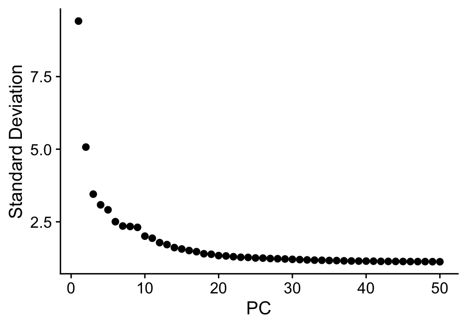

```r
ElbowPlot(obj, ndims = 50)
```

## 6. Integrate

**What:** line up the two captures so the same cell type from each sits together.

**Why:** interferon changes the expression of hundreds of genes in every cell. On top of that, the two conditions were run in different lanes. So before integration, a treated T cell and a control T cell end up far apart, and we can’t name cell types across both.

First look without integration. Always do this first. If cells already mix, you don’t need integration.

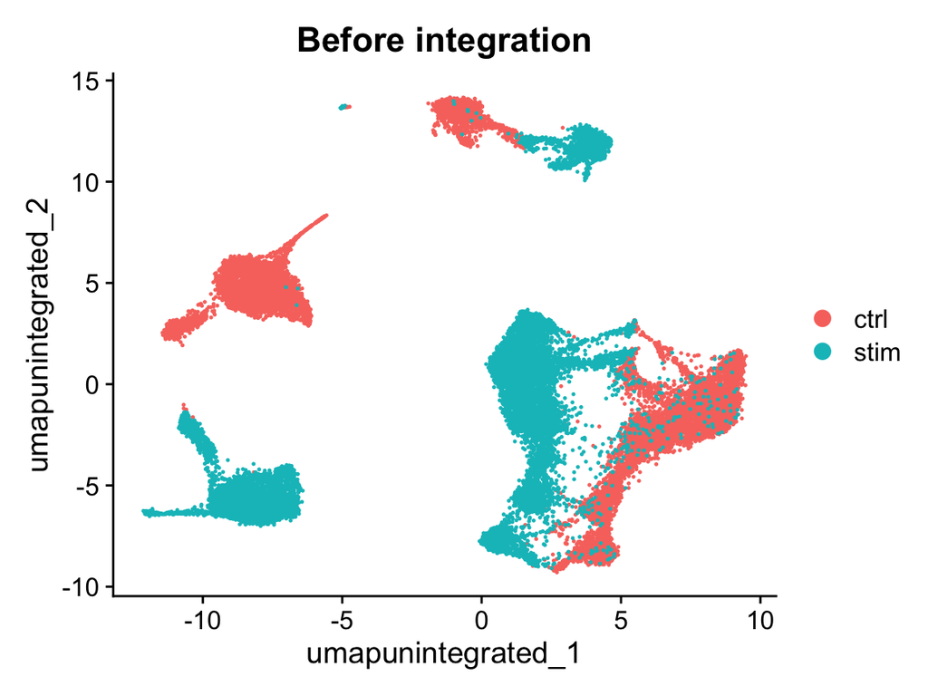

```r
obj <- RunUMAP(obj, dims = 1:30, reduction.name = "umap_unintegrated")
DimPlot(obj, reduction = "umap_unintegrated", group.by = "stim") + ggtitle("Before integration")
```

Each cell type splits into a control island and a treated island. We use Harmony, which nudges the PCA dimensions until the two groups mix within each cell type.

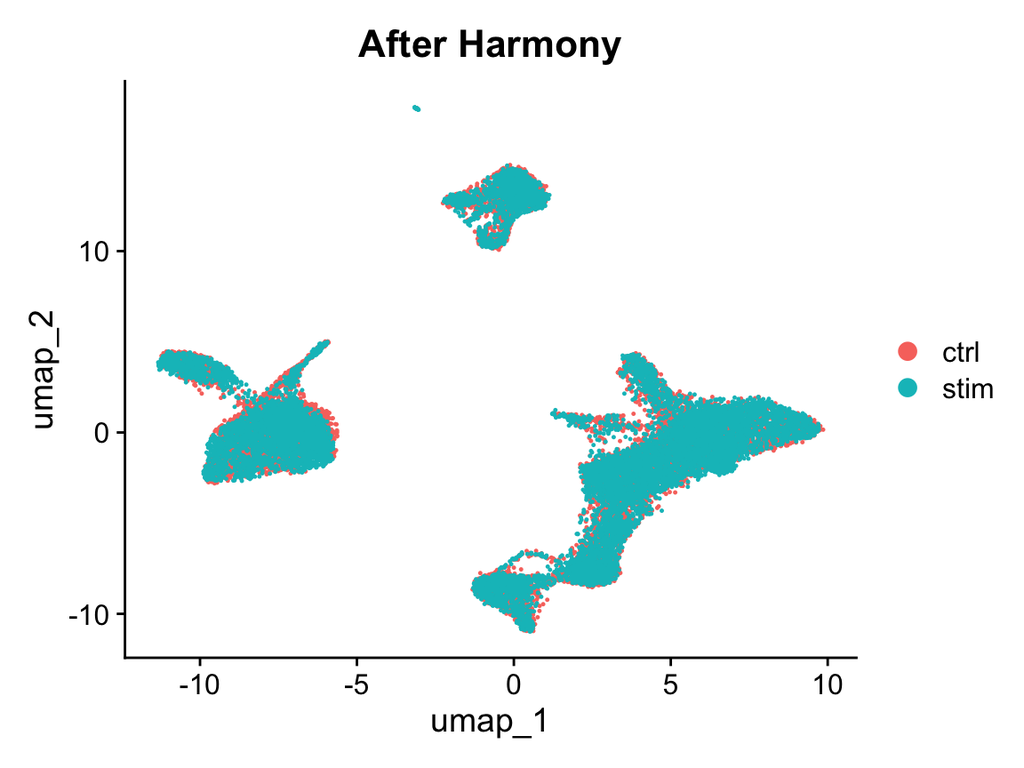

```r
obj <- RunHarmony(obj, group.by.vars = "stim")
obj <- RunUMAP(obj, reduction = "harmony", dims = 1:30)
DimPlot(obj, reduction = "umap", group.by = "stim") + ggtitle("After Harmony")
```

Important: Harmony only changes the embedding (the coordinates used for clustering and UMAP). The counts stay untouched. We never use integrated values to test genes.

## 7. Cluster and UMAP

**What:** group cells that have similar expression.

**Why:** clusters are the starting point for naming cell types.

`FindNeighbors` links each cell to the cells most like it. `FindClusters` cuts that network into groups. The `resolution` controls how many groups you get: higher means more, smaller clusters. 0.5 is a common start for PBMCs.

```r
obj <- FindNeighbors(obj, reduction = "harmony", dims = 1:30)
obj <- FindClusters(obj, resolution = 0.5)
```

```
Modularity Optimizer version 1.3.0 by Ludo Waltman and Nees Jan van Eck

Number of nodes: 22914
Number of edges: 797751

Running Louvain algorithm...
Maximum modularity in 10 random starts: 0.9038
Number of communities: 13
Elapsed time: 2 seconds
```

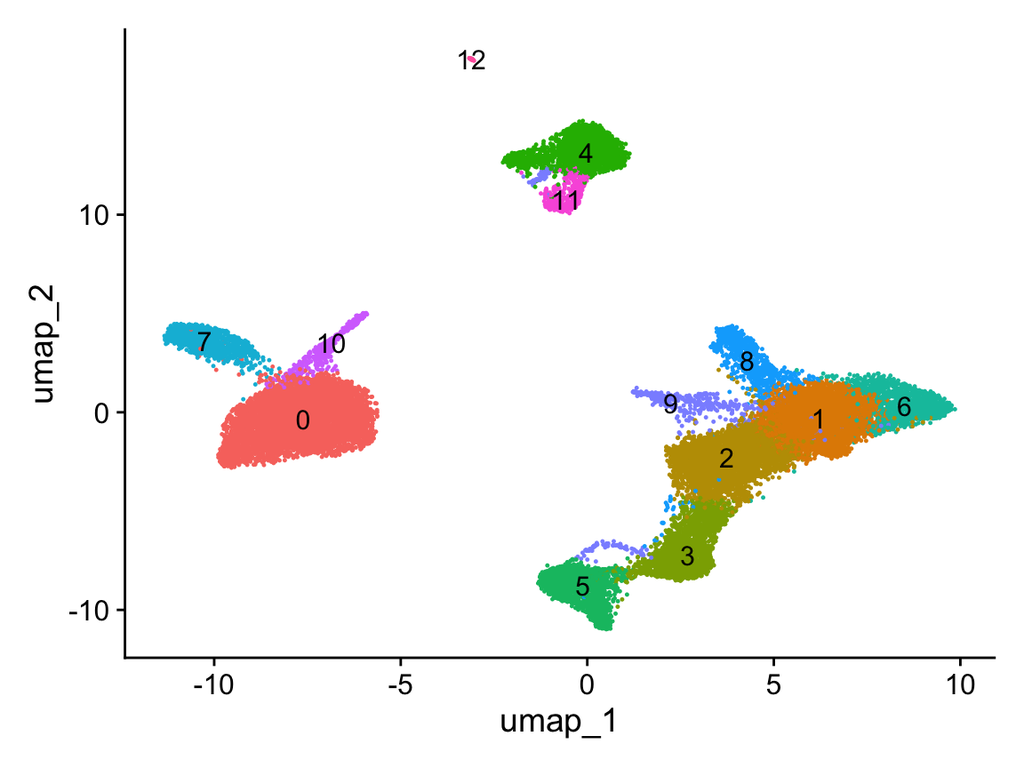

```r
DimPlot(obj, reduction = "umap", label = TRUE) + NoLegend()
```

Check that every cluster has cells from both conditions and from all donors. A cluster from only one person deserves a closer look.

```r
table(obj$seurat_clusters, obj$stim)
```

```
     ctrl stim
  0  2776 2738
  1  1977 1938
  2  1651 1730
  3   992 1036
  4  1023 1003
  5   826  806
  6   578  608
  7   503  556
  8   426  403
  9   221  252
  10  248  202
  11  190  190
  12    6   35
```

```r
table(obj$seurat_clusters, obj$ind)
```

```
      101  107 1015 1016 1039 1244 1256 1488
  0   457  377 1538  731  272  680  772  687
  1   181   90  350  250   86  630  829 1499
  2   384  193  863  259  196  530  382  574
  3   153   25  304 1077   42   81  261   85
  4   193   77  642  207   53  137  332  385
  5   145   80  338  166   36  198  417  252
  6    14   14   59   51   59  460  382  147
  7   180   43  315  167   37   57   94  166
  8    84   31  112  176   61   69  132  164
  9    33   18   65   64   22   71   89  111
  10   61   31   65   42   15  100   60   76
  11   33   20  115   21    8   52   65   66
  12    8    1    2    4    8    1    6   11
```

## 8. Find marker genes

**What:** for each cluster, find genes that are higher there than in all other clusters.

**Why:** marker genes tell you what each cluster is. For example, CD3E marks T cells and MS4A1 marks B cells.

We use the normalized RNA values from step 5 and the Wilcoxon test. The p-values here only describe the clusters. Each cell is not an independent sample, so don’t use them as real statistics.

```r
obj <- JoinLayers(obj)
markers <- FindAllMarkers(obj, only.pos = TRUE, min.pct = 0.25, logfc.threshold = 0.5)
write.csv(markers, "results/cluster_markers.csv", row.names = FALSE)

# top 5 per cluster
top5 <- markers %>% group_by(cluster) %>% slice_max(avg_log2FC, n = 5)
top5
```

```
# A tibble: 65 × 7
# Groups:   cluster [13]
       p_val avg_log2FC pct.1 pct.2 p_val_adj cluster gene
       <dbl>      <dbl> <dbl> <dbl>     <dbl> <fct>   <chr>
 1 0               9.83 0.336 0.003 0         0       CCL7
 2 0               7.12 0.717 0.023 0         0       CCL2
 3 0               7.11 0.451 0.013 0         0       CCL8
 4 0               6.83 0.663 0.012 0         0       S100A8
 5 0               6.73 0.689 0.016 0         0       S100A9
 6 0               2.38 0.273 0.055 0         1       LEF1
 7 0               2.13 0.699 0.201 0         1       SELL
 8 1.56e-281       1.98 0.322 0.094 5.15e-277 1       AES
 9 0               1.92 0.725 0.229 0         1       LTB
10 2.47e-228       1.89 0.284 0.083 8.14e-224 1       GIMAP1
# ℹ 55 more rows
```

Well-known PBMC marker genes, as a dot plot. Bigger dots mean more cells express the gene, and darker means higher expression.

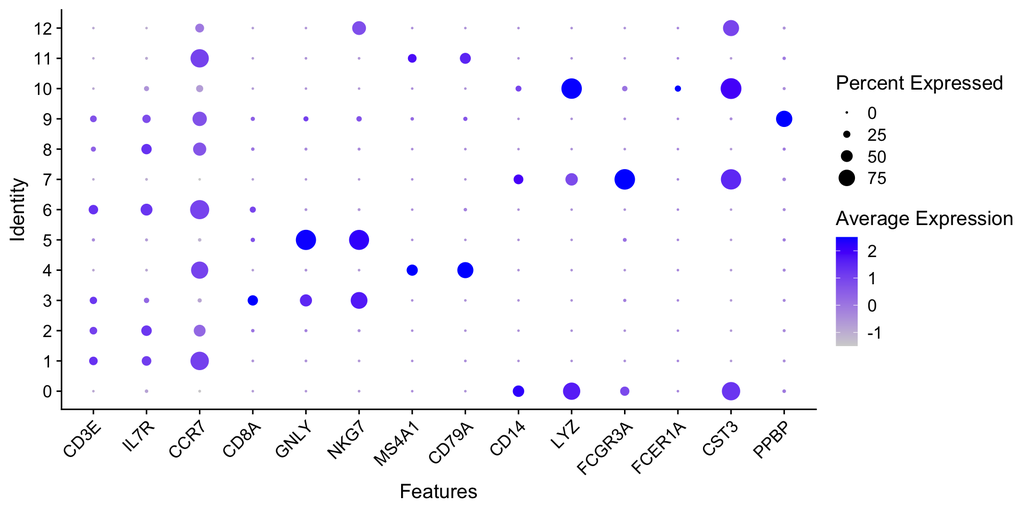

```r
known_markers <- c("CD3E", "IL7R", "CCR7", "CD8A", "GNLY", "NKG7",
                   "MS4A1", "CD79A", "CD14", "LYZ", "FCGR3A",
                   "FCER1A", "CST3", "PPBP")
DotPlot(obj, features = known_markers) + RotatedAxis()
```

## 9. Name the clusters

**What:** give each cluster a cell type name.

**Why:** the rest of the analysis is done per cell type.

**How:** first make an automatic guess from known marker genes, then check it by eye.

We write down a short list of well-known marker genes for each blood cell type. `AddModuleScore` gives every cell a score for each list: how much higher those genes are in that cell than random genes with similar expression. Each cell gets the name of its highest-scoring list.

```r
cell_type_markers <- list(
  "CD14+ Monocytes"   = c("CD14", "LYZ", "S100A8", "S100A9"),
  "FCGR3A+ Monocytes" = c("FCGR3A", "MS4A7"),
  "CD4+ T cells"      = c("CD3D", "IL7R"),
  "CD8+ T cells"      = c("CD8A", "CD8B"),
  "NK cells"          = c("GNLY", "NKG7", "KLRF1"),
  "B cells"           = c("MS4A1", "CD79A"),
  "Dendritic cells"   = c("FCER1A", "CD1C"),
  "pDC"               = c("LILRA4", "CLEC4C"),
  "Megakaryocytes"    = c("PPBP", "PF4")
)

obj <- AddModuleScore(obj, features = cell_type_markers, name = "score")

# the scores are saved as score1, score2, ... in the same order as the list
scores <- obj@meta.data[, paste0("score", 1:length(cell_type_markers))]
colnames(scores) <- names(cell_type_markers)

# each cell gets the name with the highest score
obj$marker_guess <- colnames(scores)[apply(scores, 1, which.max)]
```

Now take the most common guess in each cluster.

```r
label_table <- table(obj$seurat_clusters, obj$marker_guess)

proposed <- data.frame(
  cluster      = rownames(label_table),
  n_cells      = rowSums(label_table),
  marker_guess = colnames(label_table)[apply(label_table, 1, which.max)],
  agreement    = round(apply(label_table, 1, max) / rowSums(label_table), 2)
)
proposed$celltype <- proposed$marker_guess
proposed
```

```
   cluster n_cells      marker_guess agreement          celltype
0        0    5514   CD14+ Monocytes      0.70   CD14+ Monocytes
1        1    3915      CD4+ T cells      0.74      CD4+ T cells
2        2    3381      CD4+ T cells      0.66      CD4+ T cells
3        3    2028          NK cells      0.46          NK cells
4        4    2026           B cells      0.84           B cells
5        5    1632          NK cells      0.98          NK cells
6        6    1186      CD4+ T cells      0.56      CD4+ T cells
7        7    1059 FCGR3A+ Monocytes      0.98 FCGR3A+ Monocytes
8        8     829      CD4+ T cells      0.49      CD4+ T cells
9        9     473    Megakaryocytes      0.63    Megakaryocytes
10      10     450   CD14+ Monocytes      0.52   CD14+ Monocytes
11      11     380           B cells      0.58           B cells
12      12      41               pDC      0.71               pDC
```

```r
write.csv(proposed, "results/annotation_proposed.csv", row.names = FALSE)
```

`agreement` is the share of cells in the cluster with that guess. Low agreement means the cluster is mixed or the marker lists don’t separate it well, so check the dot plot and the top markers from step 8.

An automatic guess is only as good as its marker lists. A cluster with markers that aren’t on any list, for example stressed cells with high heat-shock genes, still gets the closest name. That is why a person checks every label.

There are other ways to make the automatic guess. Reference-based tools such as SingleR or Azimuth compare your cells to a labelled dataset. They need extra packages and a reference download, and they make mistakes too.

**Your turn.** Open `results/annotation_proposed.csv`, check each label against the dot plot and markers, change the `celltype` column if needed, and save it as `annotation_approved.csv` next to this file. If that file exists, the notebook uses it. This repository already includes ours. Clusters can come out a little different on another computer or with newer package versions. If yours don’t match ours, the notebook prints a note, uses the automatic guesses instead, and you review your own.

```r
annotation <- proposed
if (file.exists("annotation_approved.csv")) {
  approved <- read.csv("annotation_approved.csv")
  # Labels belong to specific clusters. Only use the file if it was made from these clusters.
  sizes <- table(obj$seurat_clusters)
  matches <- setequal(as.character(approved$cluster), names(sizes)) &&
    all(approved$n_cells == sizes[as.character(approved$cluster)])
  if (matches) {
    annotation <- approved
  } else {
    cat("NOTE: annotation_approved.csv was made from different clusters than yours,\n",
        "so it was not used. The labels below are the automatic guesses.\n",
        "Review results/annotation_proposed.csv and save your own annotation_approved.csv.\n")
  }
}
obj$celltype <- annotation$celltype[match(obj$seurat_clusters, annotation$cluster)]
stopifnot(!anyNA(obj$celltype))
```

As a check, compare with the labels from the original paper.

```r
table(ours = obj$celltype, paper = obj$cell)
```

```
                   paper
ours                B cells CD14+ Monocytes CD4 T cells CD8 T cells
  B cells              2343               1           3           0
  CD14+ Monocytes         0            5049           1           0
  CD4+ T cells           37              11        7875         151
  CD8+ T cells            0               0        1352        1594
  Dendritic cells         0             128           0           0
  FCGR3A+ Monocytes       0              28           0           0
  Megakaryocytes         32               0         235          39
  NK cells                0               0           3          64
  pDC                     2               0           0           0
                   paper
ours                Dendritic cells FCGR3A+ Monocytes Megakaryocytes NK cells
  B cells                        35                20              3        1
  CD14+ Monocytes                 9               422             27        6
  CD4+ T cells                    7                15             16       13
  CD8+ T cells                    0                 0              1      267
  Dendritic cells               279                43              0        0
  FCGR3A+ Monocytes               0              1028              2        1
  Megakaryocytes                  1                 2            136       28
  NK cells                        0                 1              0     1564
  pDC                            38                 1              0        0
```

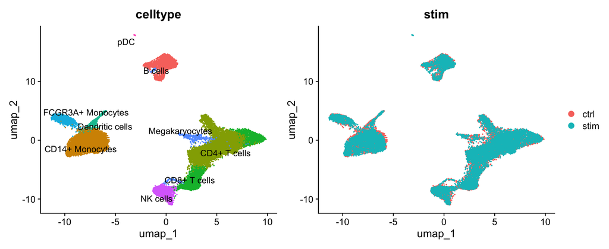

```r
DimPlot(obj, reduction = "umap", group.by = "celltype", label = TRUE, repel = TRUE) + NoLegend() +
  DimPlot(obj, reduction = "umap", group.by = "stim")
```

## 10. Differential expression between conditions

**What:** for each cell type, find genes that go up or down with interferon.

**Why pseudobulk:** the replicates in this experiment are the 8 people, not the thousands of cells. Cells from the same person are more alike than cells from different people. If you test cell by cell, you pretend you have thousands of replicates and get far too many “significant” genes.

**How:** for each cell type, add up the raw counts of all cells from each sample. That gives one column per sample, like a small bulk RNA-seq experiment. Then run DESeq2, the standard bulk tool.

Because each person has both a control and a treated sample, the design is `~ ind + stim`. This compares treated to control within each person, which removes differences between people.

```r
celltypes <- unique(obj$celltype)
de_results <- list()

for (ct in celltypes) {
  cells <- subset(obj, subset = celltype == ct)

  # only use samples with at least 10 cells of this type
  cell_counts <- table(cells$sample)
  keep_samples <- names(cell_counts)[cell_counts >= 10]

  # need at least 2 samples in each condition, or there is nothing to compare
  n_ctrl <- sum(grepl("-ctrl$", keep_samples))
  n_stim <- sum(grepl("-stim$", keep_samples))
  if (n_ctrl < 2 | n_stim < 2) {
    cat(paste0("Skipping ", ct, ": only ", n_ctrl, " control and ", n_stim,
               " treated samples have 10 or more cells.\n"))
    next
  }
  cells <- subset(cells, subset = sample %in% keep_samples)

  # add up counts per sample
  pb <- AggregateExpression(cells, assays = "RNA", group.by = "sample")$RNA
  pb <- round(as.matrix(pb))

  # sample table: which person and condition each column is
  info <- data.frame(sample = colnames(pb))
  info$ind  <- factor(cells$ind[match(info$sample, cells$sample)])
  info$stim <- factor(cells$stim[match(info$sample, cells$sample)], levels = c("ctrl", "stim"))

  # drop genes with almost no counts
  pb <- pb[rowSums(pb >= 10) >= 2, ]

  dds <- DESeqDataSetFromMatrix(pb, colData = info, design = ~ ind + stim)
  dds <- DESeq(dds, quiet = TRUE)
  res <- as.data.frame(results(dds, contrast = c("stim", "stim", "ctrl")))
  res$gene <- rownames(res)
  res$celltype <- ct
  de_results[[ct]] <- res
}
```

```
Skipping pDC: only 0 control and 0 treated samples have 10 or more cells.
```

```r
de_all <- bind_rows(de_results)
write.csv(de_all, "results/pseudobulk_DE.csv", row.names = FALSE)
```

How many genes change in each cell type (adjusted p-value under 0.05):

```r
de_summary <- de_all %>%
  group_by(celltype) %>%
  summarise(genes_tested = n(), significant = sum(padj < 0.05, na.rm = TRUE)) %>%
  arrange(desc(significant))
de_summary
```

```
# A tibble: 8 × 3
  celltype          genes_tested significant
  <chr>                    <int>       <int>
1 CD14+ Monocytes           5395        3140
2 FCGR3A+ Monocytes         2622        1325
3 CD4+ T cells              6406         925
4 Dendritic cells           1666         925
5 B cells                   3857         688
6 CD8+ T cells              4488         481
7 NK cells                  2588         469
8 Megakaryocytes             875         113
```

Interferon is a strong signal, so expect many significant genes. In CD14+ monocytes, interferon-induced genes such as CCL8, ISG20 and IFITM2 are in the top 10, and ISG15 is not far behind. Not every top gene is an interferon gene: ribosomal genes such as RPL7 go down.

```r
de_all %>% filter(celltype == de_summary$celltype[1]) %>% arrange(padj) %>% head(10)
```

```
        baseMean log2FoldChange      lfcSE      stat        pvalue
RPL7    658.5996      -2.159763 0.08081148 -26.72594 2.351751e-157
CCL8   7025.4913       9.964247 0.37702120  26.42888 6.383319e-154
RPL6    387.3201      -2.633680 0.10085513 -26.11349 2.562012e-150
ISG20  2884.5713       6.009875 0.23034865  26.09034 4.692700e-150
IL1RN   877.8711       6.722971 0.26839444  25.04885 1.797067e-138
SSB     347.6087       3.624881 0.14989222  24.18325 3.338337e-129
TMSB10 2429.2409       2.299250 0.09606988  23.93310 1.385970e-126
IFITM2  471.5635       4.951345 0.21324804  23.21871 2.946911e-119
DYNLT1  901.9296       2.753866 0.11880313  23.18008 7.232393e-119
NT5C3A  208.5972       6.258726 0.27367520  22.86918 9.419615e-116
                padj   gene        celltype
RPL7   1.268769e-153   RPL7 CD14+ Monocytes
CCL8   1.721900e-150   CCL8 CD14+ Monocytes
RPL6   4.607351e-147   RPL6 CD14+ Monocytes
ISG20  6.329279e-147  ISG20 CD14+ Monocytes
IL1RN  1.939035e-135  IL1RN CD14+ Monocytes
SSB    3.001721e-126    SSB CD14+ Monocytes
TMSB10 1.068187e-123 TMSB10 CD14+ Monocytes
IFITM2 1.987323e-116 IFITM2 CD14+ Monocytes
DYNLT1 4.335418e-116 DYNLT1 CD14+ Monocytes
NT5C3A 5.081882e-113 NT5C3A CD14+ Monocytes
```

## 11. Pathway analysis

**What:** find groups of genes (pathways) that move together.

**Why:** a list of hundreds of genes is hard to read. Pathways turn it into a few ideas, like “interferon response is up”.

**How:** GSEA (with the fgsea package). Rank every tested gene by the DESeq2 statistic, from most up to most down, and ask whether the genes of a pathway pile up at the top or bottom. It uses all genes, not just the significant ones, so it also works when few genes pass the cutoff.

Gene sets come from MSigDB: Hallmark (50 broad, well-curated sets) and Reactome (detailed pathways).

```r
hallmark <- msigdbr(species = "human", collection = "H")
reactome <- msigdbr(species = "human", collection = "C2", subcollection = "CP:REACTOME")
genesets <- rbind(hallmark, reactome)
genesets <- split(genesets$gene_symbol, genesets$gs_name)
length(genesets)
```

```
[1] 1889
```

```r
gsea_results <- list()

for (ct in names(de_results)) {
  res <- de_results[[ct]]
  res <- res[!is.na(res$stat), ]

  ranks <- res$stat
  names(ranks) <- res$gene
  ranks <- sort(ranks, decreasing = TRUE)

  gs <- fgsea(genesets, ranks, minSize = 15, maxSize = 500)
  gs$celltype <- ct
  gsea_results[[ct]] <- gs
}

gsea_all <- bind_rows(gsea_results)
gsea_all$leadingEdge <- sapply(gsea_all$leadingEdge, paste, collapse = ";")
write.csv(gsea_all, "results/gsea.csv", row.names = FALSE)
```

Top pathways for the cell type with the most significant genes. Positive NES means the pathway goes up with interferon.

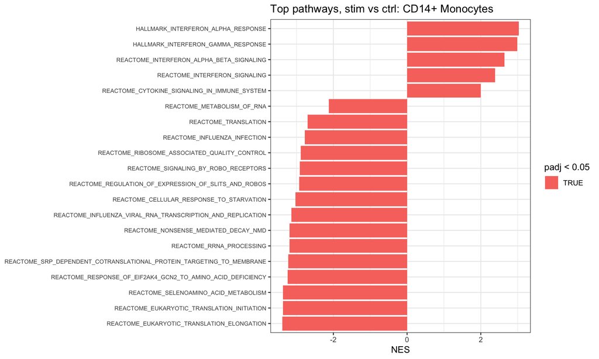

```r
top_ct <- de_summary$celltype[1]
top_paths <- gsea_all %>% filter(celltype == top_ct) %>% arrange(padj) %>% head(20)

ggplot(top_paths, aes(NES, reorder(pathway, NES), fill = padj < 0.05)) +
  geom_col() +
  labs(y = NULL, title = paste("Top pathways, stim vs ctrl:", top_ct)) +
  theme_bw() +
  theme(axis.text.y = element_text(size = 7))
```

`HALLMARK_INTERFERON_ALPHA_RESPONSE` and `HALLMARK_INTERFERON_GAMMA_RESPONSE` should be at the top. If they are, the whole pipeline worked.

## 12. Save

```r
saveRDS(obj, "results/pbmc_ifnb_annotated.rds")
```

## Where to go next

The advanced tutorial starts from raw sequencing files (FASTQ) on a computing cluster, runs Cell Ranger, and analyses single-nucleus data from human kidney. It uses SoupX with the raw droplet matrix and SCTransform normalization.